# Imports

```python
import pandas as pd
import numpy

import nltk
from nltk.corpus import stopwords
from string import punctuation
import re
from unidecode import unidecode
from collections import Counter

import geopandas
import matplotlib.pyplot as plt
from shapely.geometry import Point, Polygon


%run "../utils/dataset_parsing.ipynb"
%run "../utils/graphs.ipynb"
pd.set_option("display.max_colwidth", -1)
pd.set_option('display.max_columns', 500)
pd.set_option('display.width', 1000)
```

# Levantamos los datos

```python
df = levantar_datos()
df.info()
```

```
<class 'pandas.core.frame.DataFrame'>
RangeIndex: 240000 entries, 0 to 239999
Data columns (total 29 columns):
id                            240000 non-null int64
titulo                        234613 non-null object
descripcion                   238381 non-null object
tipodepropiedad               239954 non-null category
direccion                     186928 non-null object
ciudad                        239628 non-null category
provincia                     239845 non-null category
antiguedad                    196445 non-null float16
habitaciones                  217529 non-null float16
garages                       202235 non-null float16
banos                         213779 non-null float16
metroscubiertos               222600 non-null float32
metrostotales                 188533 non-null float32
idzona                        211379 non-null float64
lat                           116512 non-null float64
lng                           116512 non-null float64
fecha                         240000 non-null datetime64[ns]
gimnasio                      240000 non-null bool
usosmultiples                 240000 non-null bool
piscina                       240000 non-null bool
escuelascercanas              240000 non-null bool
centroscomercialescercanos    240000 non-null bool
precio                        240000 non-null float64
mes                           240000 non-null int64
ano                           240000 non-null int64
dia                           240000 non-null int64
precio_metro_cubierto         222600 non-null float64
precio_metro_total            188533 non-null float64
gps                           115871 non-null object
dtypes: bool(5), category(3), datetime64[ns](1), float16(4), float32(2), float64(6), int64(4), object(4)
memory usage: 33.2+ MB
```

# Analizamos las características generales del dataset

## Cantidad de publicaciones

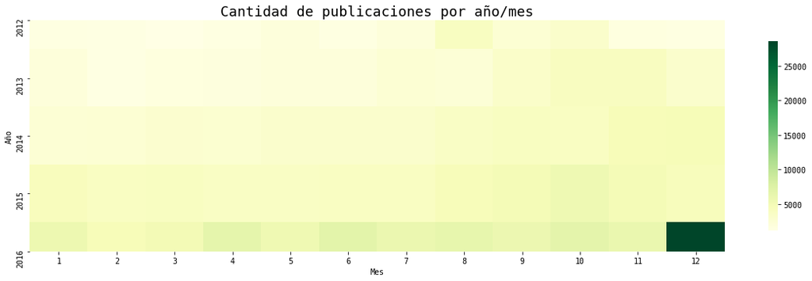

```python
grouped = df.groupby(["ano","mes"]).aggregate({"id": "count"}).unstack()
grouped.columns = grouped.columns.droplevel()
plot = get_heatmap(grouped, title="Cantidad de publicaciones por año/mes")
```

## Publicaciones por tipo de propiedad

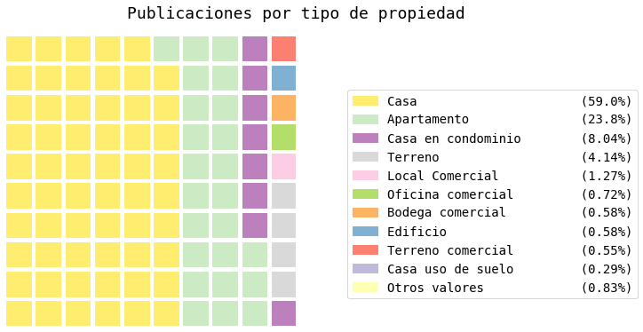

```python
waffle_tipo = get_waffleplot(df.tipodepropiedad.value_counts(normalize=True).head(10), "Publicaciones por tipo de propiedad")
```

### Distribucion de las publicaciones por año

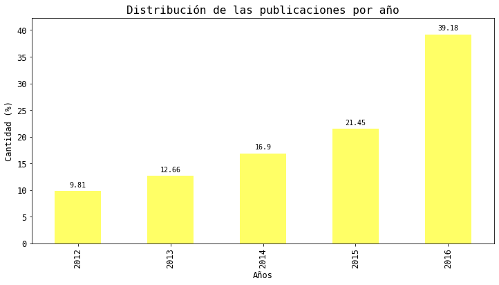

```python
por_anio = df.groupby("ano").agg({"ano":"count"}).rename(columns={'ano':'cantidad'})
total_publicaciones = df.shape[0]
por_anio_porcentual = por_anio.apply(lambda x: round(100 * x/total_publicaciones, 2), axis=0)
#histograma de ditribucion por año
get_barplot(por_anio_porcentual.cantidad, title="Distribución de las publicaciones por año", x_label="Años", y_label="Cantidad (%)")
```

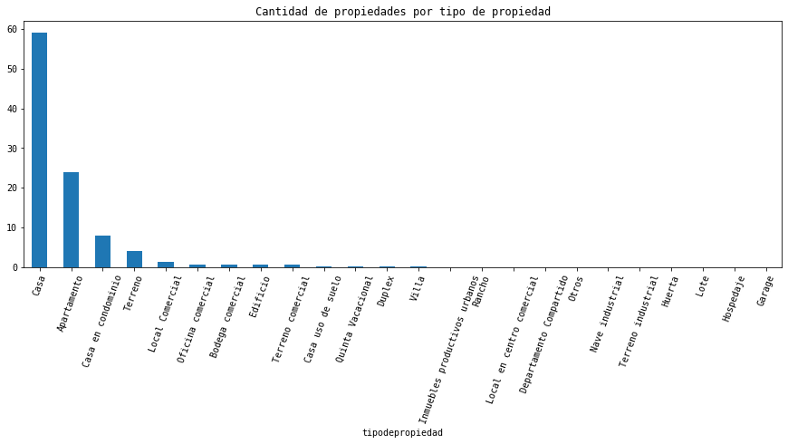

```python
por_tipo = df.groupby(["tipodepropiedad"]).agg({"tipodepropiedad":"count"}).unstack(fill_value=0).sort_values(ascending=False)
por_tipo.index = por_tipo.index.droplevel()
total_publicaciones = por_tipo.sum()
por_tipo_porcentual = por_tipo.apply(lambda x: round(100 * x/total_publicaciones, 2))
por_tipo_porcentual
por_tipo_porcentual.plot(kind='bar', figsize=(15, 5), rot=70,
                                       title="Cantidad de propiedades por tipo de propiedad");
```

```python
top_5_tipos  = por_tipo_porcentual.head(5).index.values
df_top_5 = df.loc[df["tipodepropiedad"].isin(top_5_tipos)]
por_tipo_ano = df_top_5.groupby(["ano","tipodepropiedad"]).agg({"tipodepropiedad":"count"}).unstack(fill_value=0)
por_tipo_ano.columns = por_tipo_ano.columns.droplevel()
totales = por_tipo_ano.sum(axis=1)
por_tipo_ano_porcentual = por_tipo_ano.apply(lambda x: round(100 * x/totales[x.index], 2), axis=0)
por_tipo_ano_porcentual
```

| tipodepropiedad ano | Apartamento | Casa | Casa en condominio | Local Comercial | Terreno |
| --- | --- | --- | --- | --- | --- |
| 2012 | 22.35 | 60.49 | 12.49 | 0.48 | 4.19 |
| 2013 | 22.78 | 65.70 | 6.65 | 1.11 | 3.76 |
| 2014 | 24.80 | 62.14 | 7.78 | 1.34 | 3.94 |
| 2015 | 25.80 | 60.17 | 8.27 | 1.45 | 4.31 |
| 2016 | 25.48 | 60.21 | 8.13 | 1.52 | 4.65 |

#### Representamos los datos de la tabla superior en el siguiente grafico

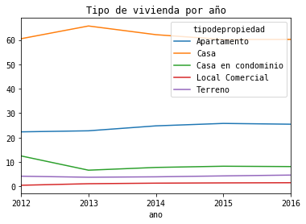

```python
por_tipo_ano_porcentual.plot(kind='line', xticks=por_tipo_ano_porcentual.index.values, title= "Tipo de vivienda por año")
```

## Precios a lo largo del tiempo

#### Se buscó información de las cotizaciones del peso mexicano respecto del dolar en el período que se corresponse a los datos de las publicaciones. El objetivo es analizar si los precios de los inmuebles en dólares se mantienen constantes o si aumentan a medida que avanza el tiempo.

```python
#Se carga el df de cotizaciones
cotizaciones = pd.read_csv("../enunciado/data/cotizacion.csv", dtype={'cotizacion':'float'}, parse_dates=["fecha"])
cotizaciones['dia'] = cotizaciones['fecha'].dt.day
cotizaciones['mes'] = cotizaciones['fecha'].dt.month
cotizaciones['anio'] = cotizaciones['fecha'].dt.year
```

```python
#Se calcula cotización promedio por mes
cotizaciones_por_mes = cotizaciones.groupby(['anio', 'mes']).agg({'cotizacion':'mean'})
cotizaciones_por_mes = cotizaciones_por_mes.reset_index()
cotizaciones_por_mes
```

|  | anio | mes | cotizacion |
| --- | --- | --- | --- |
| 0 | 2012 | 1 | 13.209137 |
| 1 | 2012 | 2 | 12.918510 |
| 2 | 2012 | 3 | 12.863155 |
| 3 | 2012 | 4 | 13.191150 |
| 4 | 2012 | 5 | 13.659909 |
| 5 | 2012 | 6 | 13.604395 |
| 6 | 2012 | 7 | 13.254914 |
| 7 | 2012 | 8 | 13.170191 |
| 8 | 2012 | 9 | 12.973638 |
| 9 | 2012 | 10 | 13.011255 |
| 10 | 2012 | 11 | 13.147762 |
| 11 | 2012 | 12 | 13.019785 |
| 12 | 2013 | 1 | 12.724495 |
| 13 | 2013 | 2 | 12.769805 |
| 14 | 2013 | 3 | 12.603817 |
| 15 | 2013 | 4 | 12.495776 |
| 16 | 2013 | 5 | 12.582588 |
| 17 | 2013 | 6 | 12.950720 |
| 18 | 2013 | 7 | 12.683148 |
| 19 | 2013 | 8 | 12.922961 |
| 20 | 2013 | 9 | 12.837600 |
| 21 | 2013 | 10 | 12.840118 |
| 22 | 2013 | 11 | 12.930650 |
| 23 | 2013 | 12 | 12.891455 |
| 24 | 2014 | 1 | 13.285652 |
| 25 | 2014 | 2 | 13.239810 |
| 26 | 2014 | 3 | 13.222843 |
| 27 | 2014 | 4 | 13.179295 |
| 28 | 2014 | 5 | 13.059386 |
| 29 | 2014 | 6 | 13.096020 |
| 30 | 2014 | 7 | 13.074800 |
| 31 | 2014 | 8 | 13.161033 |
| 32 | 2014 | 9 | 13.294116 |
| 33 | 2014 | 10 | 13.433920 |
| 34 | 2014 | 11 | 13.524000 |
| 35 | 2014 | 12 | 14.146968 |
| 36 | 2015 | 1 | 15.095175 |
| 37 | 2015 | 2 | 15.321983 |
| 38 | 2015 | 3 | 15.460090 |
| 39 | 2015 | 4 | 15.530927 |
| 40 | 2015 | 5 | 15.413314 |
| 41 | 2015 | 6 | 15.540852 |
| 42 | 2015 | 7 | 16.001522 |
| 43 | 2015 | 8 | 16.372910 |
| 44 | 2015 | 9 | 16.394800 |
| 45 | 2015 | 10 | 16.308835 |
| 46 | 2015 | 11 | 16.373758 |
| 47 | 2015 | 12 | 16.607462 |
| 48 | 2016 | 1 | 18.456500 |
| 49 | 2016 | 2 | 18.433739 |
| 50 | 2016 | 3 | 17.915517 |
| 51 | 2016 | 4 | 17.736114 |
| 52 | 2016 | 5 | 18.472223 |
| 53 | 2016 | 6 | 18.684136 |
| 54 | 2016 | 7 | 18.609077 |
| 55 | 2016 | 8 | 18.424835 |
| 56 | 2016 | 9 | 19.247333 |
| 57 | 2016 | 10 | 18.725780 |
| 58 | 2016 | 11 | 19.690976 |
| 59 | 2016 | 12 | 19.756064 |

#### Se agrega la columna mes_anio tanto en el df de cotizaciones como en el df de publicaciones para poder joinear y calcular el precio en dolares de las propiedades

```python
cotizaciones_por_mes['anio_mes'] = cotizaciones_por_mes['anio'].astype('str') + cotizaciones_por_mes['mes'].astype('str').str.zfill(width=2)
df['anio_mes'] = df['ano'].astype('str') + df['mes'].astype('str').str.zfill(width=2)

df = pd.merge(df, cotizaciones_por_mes, on='anio_mes')
df['precio_en_dolares'] = df['precio'] / df['cotizacion']
df[['precio', 'precio_en_dolares', 'cotizacion']]
```

|  | precio | precio_en_dolares | cotizacion |
| --- | --- | --- | --- |
| 0 | 2273000.0 | 138826.883316 | 16.372910 |
| 1 | 1300000.0 | 79399.449323 | 16.372910 |
| 2 | 2500000.0 | 152691.248697 | 16.372910 |
| 3 | 1850000.0 | 112991.524036 | 16.372910 |
| 4 | 3800000.0 | 232090.698020 | 16.372910 |
| ... | ... | ... | ... |
| 239995 | 2100000.0 | 164450.436009 | 12.769805 |
| 239996 | 1200000.0 | 93971.677719 | 12.769805 |
| 239997 | 1530000.0 | 119813.889092 | 12.769805 |
| 239998 | 980000.0 | 76743.536804 | 12.769805 |
| 239999 | 1260000.0 | 98670.261605 | 12.769805 |

240000 rows × 3 columns

#### Graficamos el precio promedio en dolares a lo largo del período estudiado

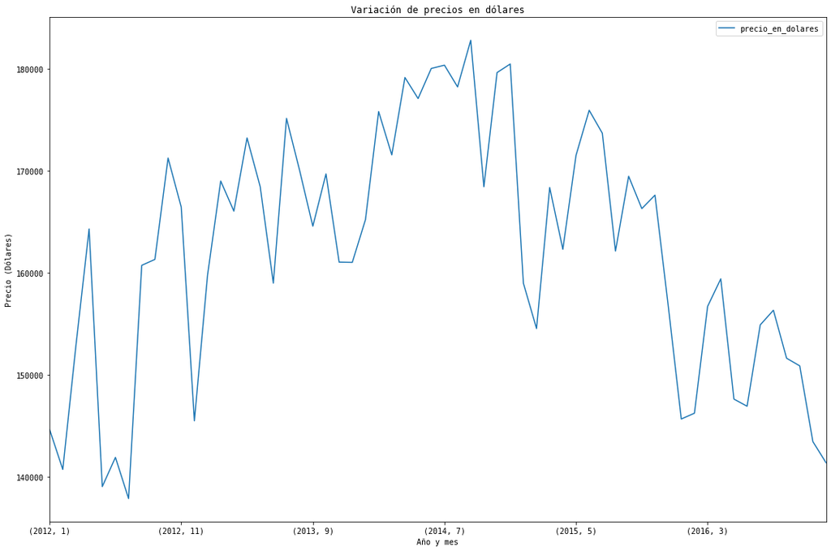

```python
precio_promedio_en_dolares = df.groupby(['ano','mes_x']).agg({'precio_en_dolares':'mean'})
ax = precio_promedio_en_dolares.plot(figsize=(18,12), title="Variación de precios en dólares")
ax.set_xlabel("Año y mes")
ax.set_ylabel("Precio (Dólares)")
```

#### Graficamos el precio promedio en pesos mexicanos a lo largo del período estudiado

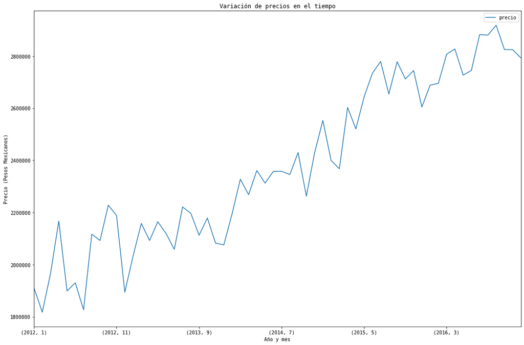

```python
precio_promedio_en_pesos_mexicanos = df.groupby(['ano','mes_x']).agg({'precio':'mean'})
ax = precio_promedio_en_pesos_mexicanos.plot(figsize=(18,12), title="Variación de precios en el tiempo")
ax.set_xlabel("Año y mes")
ax.set_ylabel("Precio (Pesos Mexicanos)")
```

#### Graficamos la variación del precio del dólar en el período

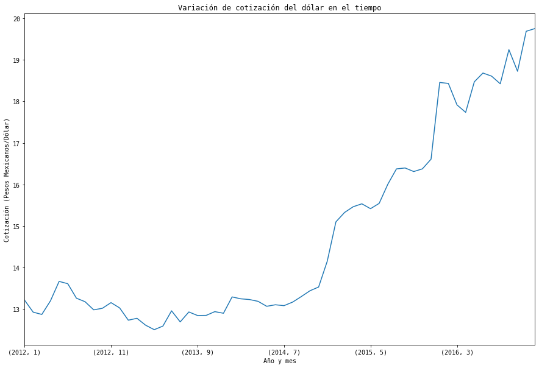

```python
cotizaciones_por_anio_mes = cotizaciones_por_mes.set_index(['anio', 'mes'])['cotizacion']
ax = cotizaciones_por_anio_mes.plot(figsize=(15,10), title="Variación de cotización del dólar en el tiempo")
ax.set_xlabel("Año y mes")
ax.set_ylabel("Cotización (Pesos Mexicanos/Dólar)")
```

## Publicaciones repetidas

### Consideramos que una publicación es igual a otra si comparten ciudad, precio, direccion, tipo de propiedad y metros totales.

```python
repetidas = df.groupby(['ciudad','provincia','precio','direccion','metrostotales','tipodepropiedad']).agg({"id":"count"})
repetidas=repetidas.loc[repetidas.id>1]
repetidas
```

| ciudad | provincia | precio | direccion | metrostotales | tipodepropiedad | id |
| --- | --- | --- | --- | --- | --- | --- |
| Aguascalientes | Aguascalientes | 1330000.0 | José Guadalupe Posada | 120.0 | Casa | 2 |
|  |  | 1995000.0 | Sierra del Humo 311 | 230.0 | Casa | 2 |
| Alvarado | Veracruz | 1890000.0 | lomas de la rioja | 158.0 | Casa | 2 |
|  |  | 2700000.0 | LOMAS DEL VALLE | 200.0 | Casa | 2 |
| Alvaro Obregón | Distrito Federal | 1400000.0 | Lomas de Plateros | 75.0 | Apartamento | 2 |
| ... | ... | ... | ... | ... | ... | ... |
| Zapopan | Jalisco | 3800000.0 | jardin de los pistaches | 228.0 | Casa | 3 |
| Zempoala | Hidalgo | 900000.0 | San Matilde Zempoala | 105.0 | Casa | 2 |
| Chiautla | México | 990000.0 | Circuito San Francisco | 71.0 | Casa | 2 |
| San Francisco de los Romo | Aguascalientes | 398000.0 | Profesor Refugio Lara Martinez L119 - M01 | 252.0 | Terreno | 2 |
|  |  | 600000.0 | San Francisco de los Romo | 250.0 | Casa | 2 |

369 rows × 1 columns

#### La cantidad de publicaciones repetidas según nuestro criterio no es significativa frente al total de los datos. Quisieramos mencionar que en el caso de diferentes departamentos con iguales caracteristicas en un mismo edificio, las publicaciones matchearán como repetidas.

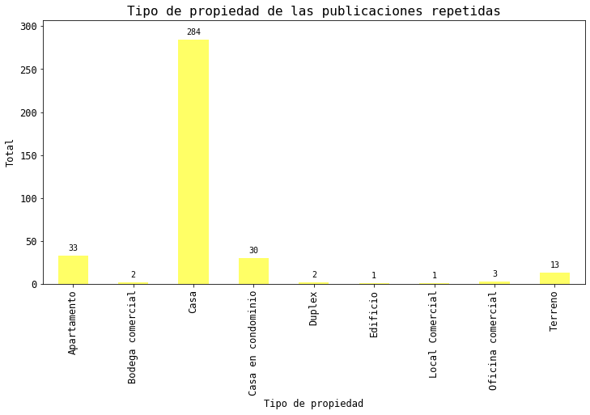

```python
repetidas=repetidas.groupby("tipodepropiedad").agg({"id":"count"})
repetidas=repetidas.rename(columns={"id":"total"})
get_barplot(repetidas["total"], title="Tipo de propiedad de las publicaciones repetidas", x_label="Tipo de propiedad", y_label="Total",)
```

#### El grafico nos permite ver que la cantidad de apartamentos repetidos es muy baja, de modo que la influencia de departamentos iguales en un edificio es casi nula.

# Conformación del precio

### Hipótesis

- En las zonas urbanas debería haber mayor cantidad de apartamentos que cualquier otro tipo de propiedad
- Si consideramos características similares los departamentos deberían ser más caros que las casas
- Las casas tienen más metros cuadrados que los departamentos (en general)
- El factor más importante para el precio de una vivienda son el tipo de propiedad y los metros cuadrados
- Las publicaciones de lugares comerciales deberían estar concentradas en lugares más céntricos

```python
import seaborn as sns
```

## Porcentaje de publicaciones de cada tipo de propiedad en cada provincia

Se quiere saber qué es lo que más se publica en cada provincia. Seguramente la mayor cantidad de publicaciones sean de departamentos o casas. En centros urbanos muy poblados, como el distrito federal, seguramente haya mayor cantidad de publicaciones de departamentos, mientras que en zonas no tan urbanizadas la cantidad de publicaciones de casas sean predominantes.

```python
#Se obtiene un dataframe con la cantidad de publicaciones de cada provincia
publicaciones_por_provincia = df.groupby('provincia').agg({'id':'count'})
publicaciones_por_provincia_y_tipo = df.groupby(['provincia', 'tipodepropiedad']).agg({'id':'count'}).reset_index()
publicaciones_por_provincia_y_tipo = pd.merge(publicaciones_por_provincia_y_tipo, publicaciones_por_provincia, on='provincia')
publicaciones_por_provincia_y_tipo = publicaciones_por_provincia_y_tipo.rename(columns={'id_x':'cantidad_tipo', 'id_y':'cantidad_total'})
publicaciones_por_provincia_y_tipo['porcentaje'] = publicaciones_por_provincia_y_tipo['cantidad_tipo'] / publicaciones_por_provincia_y_tipo['cantidad_total']
publicaciones_por_provincia_y_tipo = publicaciones_por_provincia_y_tipo.set_index(['provincia', 'tipodepropiedad'])
```

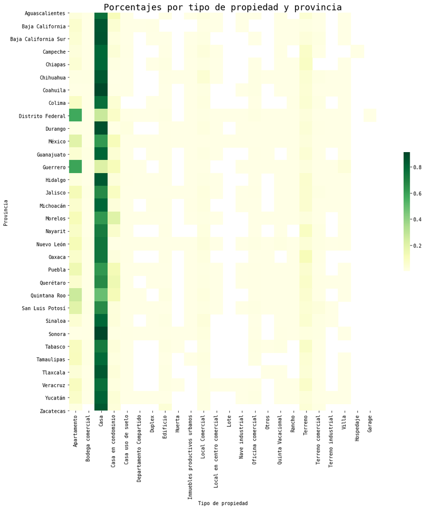

```python
publicaciones_por_provincia_y_tipo_for_heatmap = publicaciones_por_provincia_y_tipo.pivot_table(index='provincia', columns='tipodepropiedad', values='porcentaje', aggfunc='sum')
get_heatmap(publicaciones_por_provincia_y_tipo_for_heatmap, xlabel="Tipo de propiedad", ylabel="Provincia", title="Porcentajes por tipo de propiedad y provincia")
```

#### Se puede visualizar en el heatmap que en general la cantidad de publicaciones de casas es muy grande, en relación con los demás tipos de propiedades.

Efectivamente en el distrito federal la cantidad de departamento es muy alta en comparación con las casas. Lo mismo ocurre en Guerrero.

## Relación entre tipo de propiedad y precio

A continuación intentaremos determinar el impacto que tiene el tipo de propiedad en el precio. Para ello nos concetraremos primero en el grupo de tipos de propiedad correspondiente a las viviendas. Este grupo tendrá los inmuebles de tipo: Apartamento, Casa, Casa en condominio, Casa uso de suelo, Departamento Compartido y Duplex.

```python
# Obtenemos un df con las publicaciones de viviendas
tipo_vivienda = ['Apartamento', 'Casa', 'Casa en condominio', 'Casa uso de suelo', 'Departamento Compartido', 'Duplex']
publicaciones_viviendas = df.set_index('tipodepropiedad')
publicaciones_viviendas = publicaciones_viviendas.filter(items=tipo_vivienda, axis=0)
publicaciones_viviendas.reset_index(inplace=True)
```

Por ahora tomemos este df tal como está y comparemos los precios utilizando un Boxplot.

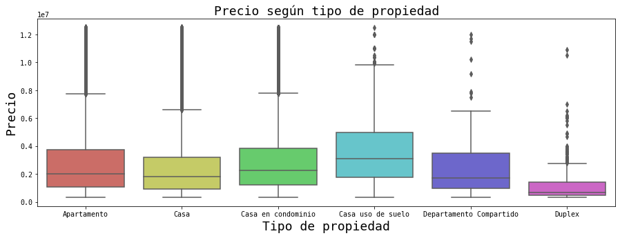

```python
get_boxplot(publicaciones_viviendas, 'tipodepropiedad', 'precio', (15,5), label_x='Tipo de propiedad', label_y='Precio', title='Precio según tipo de propiedad')
```

Tener en cuenta que la escala de precios es 1e7, por lo tanto 0.2 es 2,000,000.00. A simple vista los apartamentos, las casas y las casas en condominio tienen precios similares (en promedio). El problema de este análisis es que no se tiene en cuenta que existen otros factores que podrían variar el precio, por ejemplo los metros cuadrados. Es decir si una casa y un apartamento tienen metros cuadrados similares, ¿El precio también es similar?.

### Relación entre tipo de propiedad, metros cuadrados y precio

Primero verifiquemos que todas las propiedades tienen los valores de metros cuadrados.

```python
publicaciones_viviendas.isnull().sum()
```

```
tipodepropiedad               0
id                            0
titulo                        5054
descripcion                   1458
direccion                     47522
ciudad                        330
provincia                     143
antiguedad                    34858
habitaciones                  4760
garages                       31185
banos                         10918
metroscubiertos               8054
metrostotales                 46972
idzona                        25836
lat                           113502
lng                           113502
fecha                         0
gimnasio                      0
usosmultiples                 0
piscina                       0
escuelascercanas              0
centroscomercialescercanos    0
precio                        0
mes_x                         0
ano                           0
dia                           0
precio_metro_cubierto         8054
precio_metro_total            46972
gps                           114068
tiene_gps                     0
coord                         113502
en_mexico                     113502
anio_mes                      0
anio                          0
mes_y                         0
cotizacion                    0
precio_en_dolares             0
dtype: int64
```

```python
publicaciones_viviendas.loc[(publicaciones_viviendas['metroscubiertos'].isnull()) & (publicaciones_viviendas['metrostotales'].isnull())]
```

|  | tipodepropiedad | id | titulo | descripcion | direccion | ciudad | provincia | antiguedad | habitaciones | garages | banos | metroscubiertos | metrostotales | idzona | lat | lng | fecha | gimnasio | usosmultiples | piscina | escuelascercanas | centroscomercialescercanos | precio | mes_x | ano | dia | precio_metro_cubierto | precio_metro_total | gps | … |
| --- | --- | --- | --- | --- | --- | --- | --- | --- | --- | --- | --- | --- | --- | --- | --- | --- | --- | --- | --- | --- | --- | --- | --- | --- | --- | --- | --- | --- | --- | --- |

Como se observa hay publicaciones que no tienen los metros cuadrados cubiertos o bien no tienen los metros cuadrados totales, pero no hay ninguna que no tenga ninguno de los 2 datos. Esto podría indicar que en caso que los metros totales estén en null, significa que los metros cubiertos son los metros totales y viceversa. Para no dejar fuera del análisis estas publicaciones consideraremos que lo dicho anteriormente es cierto, por lo tanto actualizaremos los valores.

```python
publicaciones_viviendas.loc[publicaciones_viviendas['metroscubiertos'].isnull(), ['metroscubiertos']] = publicaciones_viviendas['metrostotales']
publicaciones_viviendas.loc[publicaciones_viviendas['metrostotales'].isnull(), ['metrostotales']] = publicaciones_viviendas['metroscubiertos']
#Verificamos que no haya valores en 0
publicaciones_viviendas.loc[publicaciones_viviendas['metrostotales'] == 0]
```

|  | tipodepropiedad | id | titulo | descripcion | direccion | ciudad | provincia | antiguedad | habitaciones | garages | banos | metroscubiertos | metrostotales | idzona | lat | lng | fecha | gimnasio | usosmultiples | piscina | escuelascercanas | centroscomercialescercanos | precio | mes_x | ano | dia | precio_metro_cubierto | precio_metro_total | gps | … |
| --- | --- | --- | --- | --- | --- | --- | --- | --- | --- | --- | --- | --- | --- | --- | --- | --- | --- | --- | --- | --- | --- | --- | --- | --- | --- | --- | --- | --- | --- | --- |

Ahora que todas las propiedades tienen valores en el campo metros cuadrados es necesario determinar un rango de análisis. Análiamos con un histograma en qué rangos se encuentran aproximadamente la mayor cantidad de publicaciones.

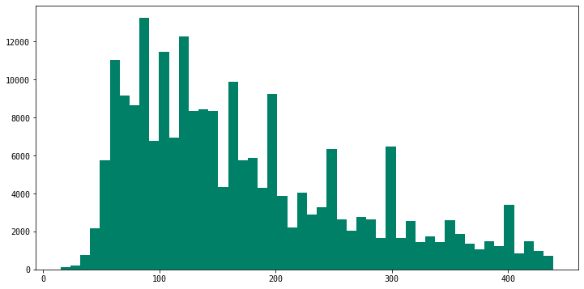

```python
get_hist(publicaciones_viviendas["metrostotales"], bins=50)
```

```python
publicaciones_entre_120_y_130 = publicaciones_viviendas.loc[(publicaciones_viviendas["metrostotales"] >= 120) & (publicaciones_viviendas["metrostotales"] <= 130)]
publicaciones_entre_120_y_130.groupby("tipodepropiedad").agg({"id":"count"})
```

| tipodepropiedad | id |
| --- | --- |
| Apartamento | 3626 |
| Casa | 11245 |
| Casa en condominio | 1442 |
| Casa uso de suelo | 38 |
| Departamento Compartido | 11 |
| Duplex | 16 |

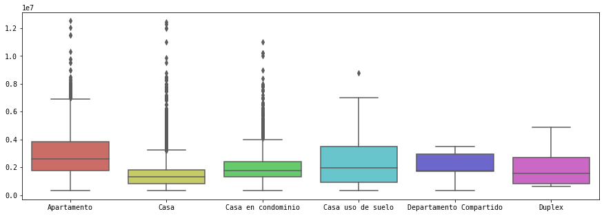

```python
get_boxplot(publicaciones_entre_120_y_130, 'tipodepropiedad', 'precio', (15,5))
```

De este gráfico sólo podemos considerar válidos los datos de departamentos, casas y casas en condominio, dado que la cantidad de muestras de los demás tipos de propiedades no es representativo. Si consideramos propiedades de metros similares vemos que los departamentos son más caros. Entonces por qué en el gráfico anterior mostraba que las casas y los departamentos tienen precios similares y aquí no ocurre eso? Es de suponer que la casas tienen más metros cuadrados que los departamentos en general, por lo tanto si tomamos las propiedades sin limitar las demás características las casas tienden a tener precios similares a los departamentos por la cantidad de metros cuadrados. Lo anterior se puede verificar con el siguiente gráfico.

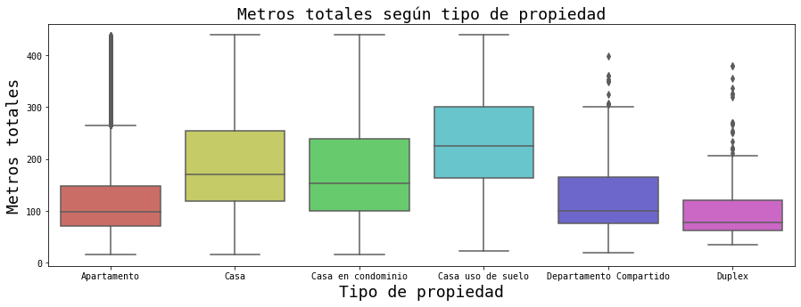

```python
get_boxplot(publicaciones_viviendas, 'tipodepropiedad', 'metrostotales', (15,5), title="Metros totales según tipo de propiedad", label_x="Tipo de propiedad", label_y="Metros totales")
```

En el siguiente gráfico se puede observar el cambio de precio según la cantidad de metros cuadrados, por tipo de propiedad.

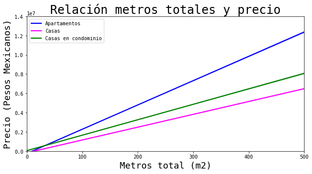

```python
publicaciones_apartamentos = publicaciones_viviendas.loc[publicaciones_viviendas['tipodepropiedad'] == 'Apartamento']
publicaciones_casas = publicaciones_viviendas.loc[publicaciones_viviendas['tipodepropiedad'] == 'Casa']
publicaciones_casas_condominio = publicaciones_viviendas.loc[publicaciones_viviendas['tipodepropiedad'] == 'Casa en condominio']
f, ax = plt.subplots(figsize=(10,5))
ax.set(xlim=(0, 500), ylim=(0, 14000000))
#sns.scatterplot(x='metrostotales', y='precio', data=publicaciones_viviendas.loc[publicaciones_viviendas['tipodepropiedad'] == 'Apartamento'])
sns.regplot(x=publicaciones_apartamentos['metrostotales'],y=publicaciones_apartamentos['precio'],color='blue',scatter=False)
sns.regplot(x=publicaciones_casas['metrostotales'],y=publicaciones_casas['precio'],color='magenta',scatter=False)
sns.regplot(x=publicaciones_casas_condominio['metrostotales'],y=publicaciones_casas_condominio['precio'],color='green',scatter=False)

plt.legend(labels=['Apartamentos','Casas','Casas en condominio'])
plt.title('Relación metros totales y precio', size=24)
plt.xlabel('Metros total (m2)', size=18)
plt.ylabel('Precio (Pesos Mexicanos)', size=18);
```

### Antigüedad

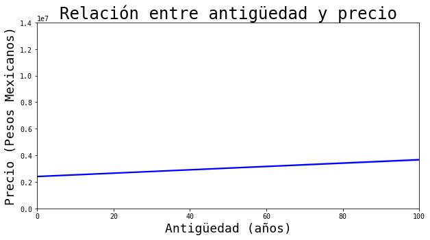

```python
f, ax=plt.subplots(figsize=(10,5))
ax.set(xlim=(0, 100), ylim=(0, 14000000))
sns.regplot(x='antiguedad',y='precio',data=publicaciones_viviendas, color='blue',scatter=False)

plt.title('Relación entre antigüedad y precio', size=24)
plt.xlabel('Antigüedad (años)', size=18)
plt.ylabel('Precio (Pesos Mexicanos)', size=18);
```

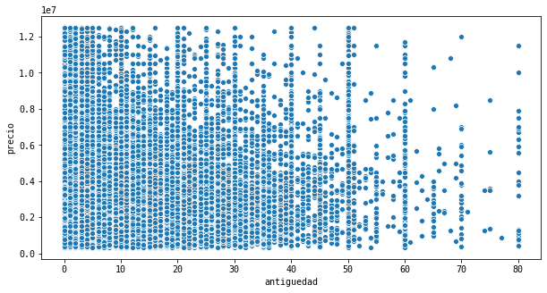

```python
plt.subplots(figsize=(10,5))
sns.scatterplot(x='antiguedad', y='precio', data=publicaciones_viviendas)
```

Como se aprecia en la línea de regresión el precio no varía practicamente con la antiguedad. Al haber pocas publicaciones con muchos años de antigüedad este valor también es más impreciso.

El aumento de precio a medida que la antigüedad es mayor también puede deberse a que hay mayor cantidad de metros cuadrados en construcciones más antiguas.

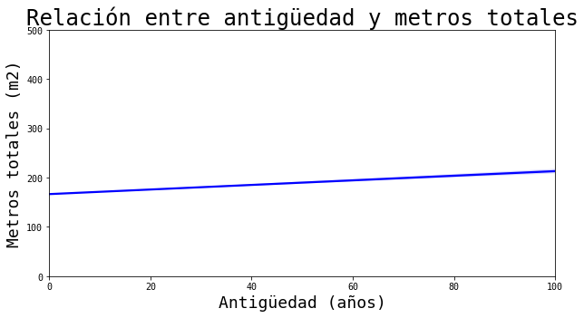

```python
f, ax=plt.subplots(figsize=(10,5))
ax.set(xlim=(0, 100), ylim=(0, 500))
sns.regplot(x='antiguedad',y='metrostotales',data=publicaciones_viviendas, color='blue',scatter=False)

plt.title('Relación entre antigüedad y metros totales', size=24)
plt.xlabel('Antigüedad (años)', size=18)
plt.ylabel('Metros totales (m2)', size=18);
```

### Baños y habitaciones

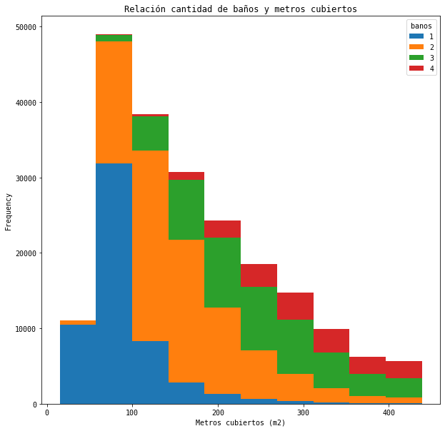

```python
convert_dict={'banos':'int'}
publicaciones_viviendas_con_bano = publicaciones_viviendas.loc[~publicaciones_viviendas['banos'].isnull(), ['banos','metroscubiertos']].astype(convert_dict)
ax = publicaciones_viviendas_con_bano.pivot(columns='banos')['metroscubiertos'].plot(kind = 'hist', stacked=True, figsize=(10,10), title="Relación cantidad de baños y metros cubiertos")
ax.set_xlabel("Metros cubiertos (m2)")
```

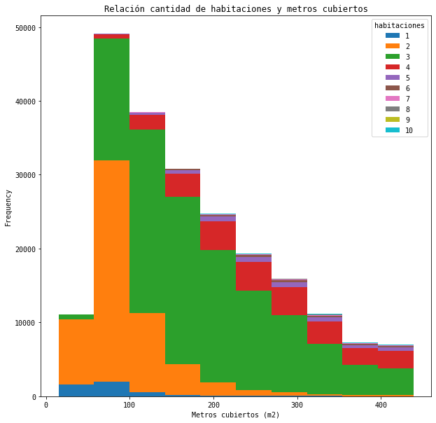

```python
convert_dict={'habitaciones':'int'}
publicaciones_viviendas_con_habitaciones = publicaciones_viviendas.loc[~publicaciones_viviendas['habitaciones'].isnull(), ['habitaciones','metroscubiertos']].astype(convert_dict)
ax = publicaciones_viviendas_con_habitaciones.pivot(columns='habitaciones')['metroscubiertos'].plot(kind = 'hist', stacked=True, figsize=(10,10), title="Relación cantidad de habitaciones y metros cubiertos")
ax.set_xlabel("Metros cubiertos (m2)")
```

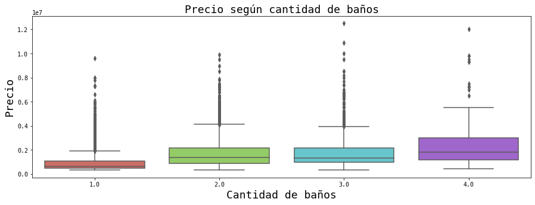

```python
precio_viviendas_con_bano_90_a_100 = publicaciones_viviendas.loc[(~publicaciones_viviendas['banos'].isnull()) & (publicaciones_viviendas['metrostotales'] >= 90) & (publicaciones_viviendas['metrostotales'] <= 100)]
get_boxplot(precio_viviendas_con_bano_90_a_100, 'banos', 'precio', (15,5), title="Precio según cantidad de baños", label_x="Cantidad de baños", label_y="Precio")
```

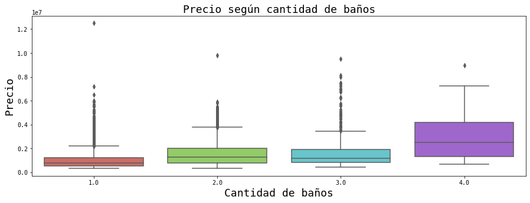

```python
precio_viviendas_con_bano_70_a_80 = publicaciones_viviendas.loc[(~publicaciones_viviendas['banos'].isnull()) & (publicaciones_viviendas['metrostotales'] >= 70) & (publicaciones_viviendas['metrostotales'] <= 80)]
get_boxplot(precio_viviendas_con_bano_70_a_80, 'banos', 'precio', (15,5), title="Precio según cantidad de baños", label_x="Cantidad de baños", label_y="Precio")
```

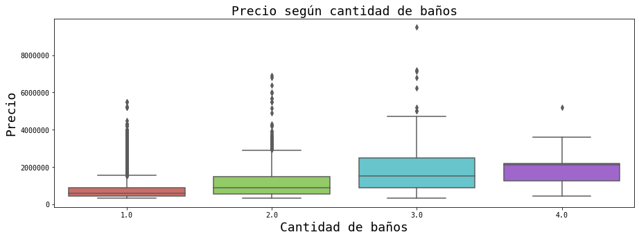

```python
precio_viviendas_con_bano_50_a_60 = publicaciones_viviendas.loc[(~publicaciones_viviendas['banos'].isnull()) & (publicaciones_viviendas['metrostotales'] >= 50) & (publicaciones_viviendas['metrostotales'] <= 60)]
get_boxplot(precio_viviendas_con_bano_50_a_60, 'banos', 'precio', (15,5), title="Precio según cantidad de baños", label_x="Cantidad de baños", label_y="Precio")
```

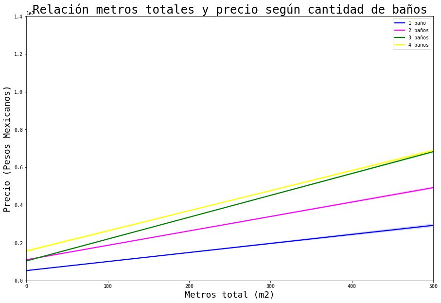

```python
publicaciones_1_bano = publicaciones_viviendas.loc[(~publicaciones_viviendas['banos'].isnull()) & (publicaciones_viviendas['banos'] == 1)]
publicaciones_2_bano = publicaciones_viviendas.loc[(~publicaciones_viviendas['banos'].isnull()) & (publicaciones_viviendas['banos'] == 2)]
publicaciones_3_bano = publicaciones_viviendas.loc[(~publicaciones_viviendas['banos'].isnull()) & (publicaciones_viviendas['banos'] == 3)]
publicaciones_4_bano = publicaciones_viviendas.loc[(~publicaciones_viviendas['banos'].isnull()) & (publicaciones_viviendas['banos'] == 4)]
f, ax = plt.subplots(figsize=(15,10))
ax.set(xlim=(0, 500), ylim=(0, 14000000))
#sns.scatterplot(x='metrostotales', y='precio', data=publicaciones_viviendas.loc[publicaciones_viviendas['tipodepropiedad'] == 'Apartamento'])
sns.regplot(x=publicaciones_1_bano['metrostotales'],y=publicaciones_1_bano['precio'],color='blue',scatter=False)
sns.regplot(x=publicaciones_2_bano['metrostotales'],y=publicaciones_2_bano['precio'],color='magenta',scatter=False)
sns.regplot(x=publicaciones_3_bano['metrostotales'],y=publicaciones_3_bano['precio'],color='green',scatter=False)
sns.regplot(x=publicaciones_4_bano['metrostotales'],y=publicaciones_4_bano['precio'],color='yellow',scatter=False)

plt.legend(labels=['1 baño','2 baños','3 baños', '4 baños'])
plt.title('Relación metros totales y precio según cantidad de baños', size=24)
plt.xlabel('Metros total (m2)', size=18)
plt.ylabel('Precio (Pesos Mexicanos)', size=18);
```

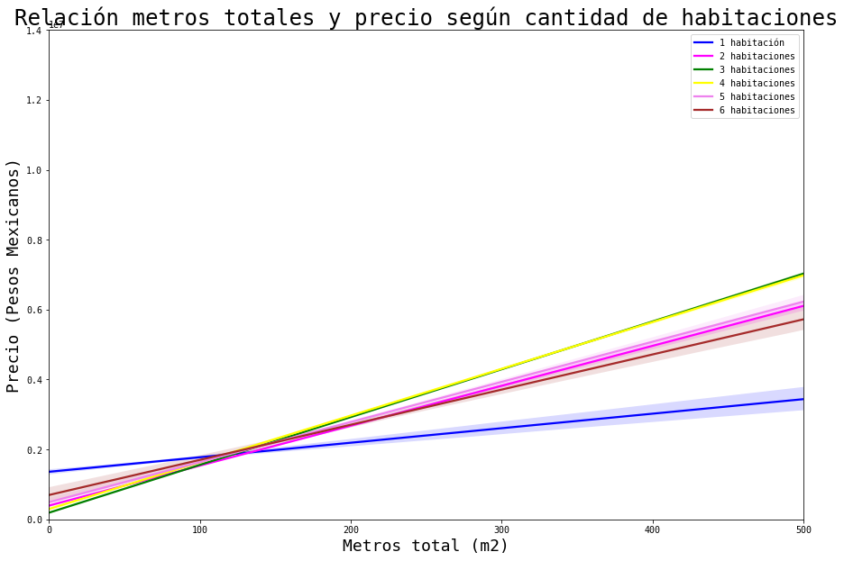

```python
publicaciones_1_habitacion = publicaciones_viviendas.loc[(~publicaciones_viviendas['habitaciones'].isnull()) & (publicaciones_viviendas['habitaciones'] == 1)]
publicaciones_2_habitacion = publicaciones_viviendas.loc[(~publicaciones_viviendas['habitaciones'].isnull()) & (publicaciones_viviendas['habitaciones'] == 2)]
publicaciones_3_habitacion = publicaciones_viviendas.loc[(~publicaciones_viviendas['habitaciones'].isnull()) & (publicaciones_viviendas['habitaciones'] == 3)]
publicaciones_4_habitacion = publicaciones_viviendas.loc[(~publicaciones_viviendas['habitaciones'].isnull()) & (publicaciones_viviendas['habitaciones'] == 4)]
publicaciones_5_habitacion = publicaciones_viviendas.loc[(~publicaciones_viviendas['habitaciones'].isnull()) & (publicaciones_viviendas['habitaciones'] == 5)]
publicaciones_6_habitacion = publicaciones_viviendas.loc[(~publicaciones_viviendas['habitaciones'].isnull()) & (publicaciones_viviendas['habitaciones'] == 6)]

f, ax = plt.subplots(figsize=(15,10))
ax.set(xlim=(0, 500), ylim=(0, 14000000))
#sns.scatterplot(x='metrostotales', y='precio', data=publicaciones_viviendas.loc[publicaciones_viviendas['tipodepropiedad'] == 'Apartamento'])
sns.regplot(x=publicaciones_1_habitacion['metrostotales'],y=publicaciones_1_habitacion['precio'],color='blue',scatter=False)
sns.regplot(x=publicaciones_2_habitacion['metrostotales'],y=publicaciones_2_habitacion['precio'],color='magenta',scatter=False)
sns.regplot(x=publicaciones_3_habitacion['metrostotales'],y=publicaciones_3_habitacion['precio'],color='green',scatter=False)
sns.regplot(x=publicaciones_4_habitacion['metrostotales'],y=publicaciones_4_habitacion['precio'],color='yellow',scatter=False)
sns.regplot(x=publicaciones_5_habitacion['metrostotales'],y=publicaciones_5_habitacion['precio'],color='violet',scatter=False)
sns.regplot(x=publicaciones_6_habitacion['metrostotales'],y=publicaciones_6_habitacion['precio'],color='brown',scatter=False)

plt.legend(labels=['1 habitación','2 habitaciones','3 habitaciones', '4 habitaciones', '5 habitaciones', '6 habitaciones'])
plt.title('Relación metros totales y precio según cantidad de habitaciones', size=24)
plt.xlabel('Metros total (m2)', size=18)
plt.ylabel('Precio (Pesos Mexicanos)', size=18);
```

## Amenities y cercanías

Analizamos la influencia de los amenities y las cercanías a escuelas y/o centro comerciales

```python
df['tiene_amenities'] = (df["gimnasio"] + df["usosmultiples"] + df["piscina"]) > 0
df['tiene_cercanias'] = (df["centroscomercialescercanos"] + df["escuelascercanas"]) > 0
```

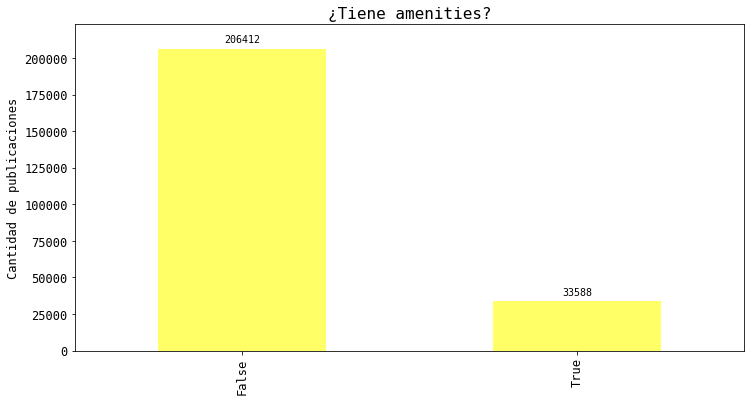

```python
ameneties=df.groupby(["tiene_amenities"]).agg({"id":"count"})
ameneties=ameneties.rename(columns={"id":"cantidad"})
get_barplot(ameneties["cantidad"], title="¿Tiene amenities?", y_label="Cantidad de publicaciones")
```

Vemos como se distribuyen los amenities entre las publicaciones según el tipo de propiedad del que se trate

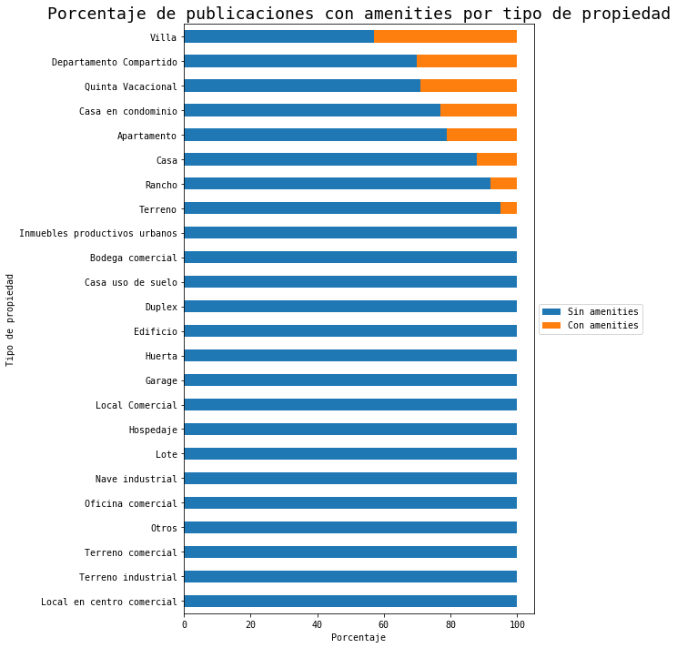

```python
amenities_por_tipo = df.groupby(["tipodepropiedad","tiene_amenities"]).agg({"id":"count"}).unstack(fill_value=0)
amenities_por_tipo.columns = ["No", "Sí"]
amenities_por_tipo = (amenities_por_tipo.div(amenities_por_tipo.sum(axis=1), axis=0) * 100).apply(lambda x: round(x,0)).sort_values(by="Sí", ascending=True)
plot = amenities_por_tipo.plot(kind = 'barh', stacked=True, figsize=(10,10))
plot.legend(labels=["Sin amenities", "Con amenities"],loc='center left', bbox_to_anchor=(1, 0.5))
plot.set_title("Porcentaje de publicaciones con amenities por tipo de propiedad", fontdict={"fontsize": 18})
plot.set_xlabel("Porcentaje")
plot.set_ylabel("Tipo de propiedad")
plt.tight_layout()
```

Vemos como afecta al precio la precencia de amenities a las publicaciones según el tipo de propiedad del que se trate

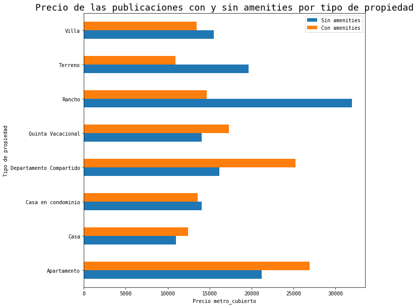

```python
tipos_con_amenities = amenities_por_tipo.loc[amenities_por_tipo["No"] < 100].index.values
precio_amenities_por_tipo = df.loc[df["tipodepropiedad"].isin(tipos_con_amenities)].groupby(["tipodepropiedad","tiene_amenities"]).agg({"precio_metro_cubierto":"mean"}).dropna().unstack()
precio_amenities_por_tipo.columns = ["Sin amenities", "Con amenities"]
plot = precio_amenities_por_tipo.plot(kind = 'barh', stacked=False, figsize=(10,10), title="Precio de las publicaciones con y sin amenities por tipo de propiedad")
plot.set_xlabel("Precio metro_cubierto")
plot.set_ylabel("Tipo de propiedad")
plot.set_title("Precio de las publicaciones con y sin amenities por tipo de propiedad", fontdict={"fontsize": 18})
```

Analizamos la influencia de cercanías a escuelas y/o centro comerciales

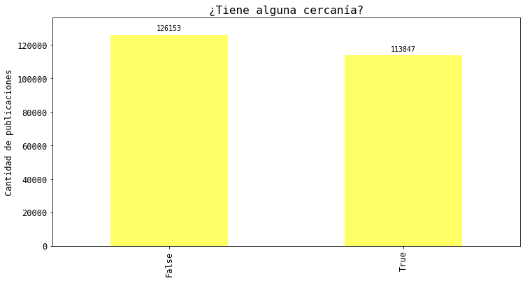

```python
cercanias = df.groupby(["tiene_cercanias"]).agg({"id":"count"})
cercanias = cercanias.rename(columns={"id":"cantidad"})
get_barplot(cercanias["cantidad"], title="¿Tiene alguna cercanía?", y_label="Cantidad de publicaciones")
```

Vemos como se distribuyen las cercanías entre las publicaciones según el tipo de propiedad del que se trate

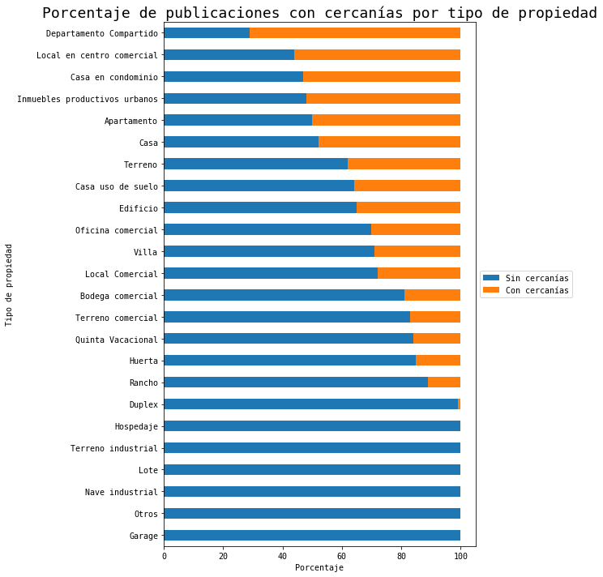

```python
cercanias_por_tipo = df.groupby(["tipodepropiedad","tiene_cercanias"]).agg({"id":"count"}).unstack(fill_value=0)
cercanias_por_tipo.columns = ["No", "Sí"]
cercanias_por_tipo = (cercanias_por_tipo.div(cercanias_por_tipo.sum(axis=1), axis=0) * 100).apply(lambda x: round(x,0)).sort_values(by="Sí", ascending=True)
plot = cercanias_por_tipo.plot(kind = 'barh', stacked=True, figsize=(10,10))
plot.legend(labels=["Sin cercanías", "Con cercanías"],loc='center left', bbox_to_anchor=(1, 0.5))
plot.set_title("Porcentaje de publicaciones con cercanías por tipo de propiedad", fontdict={"fontsize": 18})
plot.set_xlabel("Porcentaje")
plot.set_ylabel("Tipo de propiedad")
plt.tight_layout()
```

[figure not shown]

```python
tipos_con_cercanias = cercanias_por_tipo.loc[cercanias_por_tipo["No"] < 100].index.values
precio_cercanias_por_tipo = df.loc[df["tipodepropiedad"].isin(tipos_con_cercanias)].groupby(["tipodepropiedad","tiene_amenities"]).agg({"precio_metro_cubierto":"mean"}).dropna().unstack()
precio_cercanias_por_tipo.columns = ["Sin cercanias", "Con cercanias"]
plot = precio_cercanias_por_tipo.plot(kind = 'barh', stacked=False, figsize=(10,10), title="Precio de las publicaciones con y sin cercanias por tipo de propiedad")
plot.set_xlabel("Precio metro_cubierto")
plot.set_ylabel("Tipo de propiedad")
plot.set_title("Precio de las publicaciones con y sin cercanias por tipo de propiedad", fontdict={"fontsize": 18})
```